# Interactive Central Limit Theorem

medianvoter

5 November 2018

## Motivation

- The Central Limit Theorem is an important statistical concept
- But it is not very intuitive
- This app explains the Central Limit Theorem interactively by allowing users to choose
  - Distribution: normal, uniform, Poisson, exponential
  - Sample size
  - Number of Samples
- By adjusting the number of samples, the user will be able to see the distribution of means gradually becoming normal, thus demostrating the Central Limit Theorem
- Github repo: https://github.com/medianvoter/shiny
- Shiny app: https://medvoter.shinyapps.io/shiny/

## UI Code Demonstration

The UI page takes user input in the sidebar for sample size and number of samples (from sliders) and distribution type (from a radio button).

```r
h4("Pick sample size"),
# Sample size slider input
sliderInput("sampleSize", "Sample size", value = 50, min = 10, max = 100),
# Number of samples slider input
h4("Pick number of samples"),
sliderInput("numSamples", "Number of Samples", value = 1000,
            min = 10, max = 10000),
# Distribution type radio button
h4("Pick distribution"),
radioButtons("dist", "Distribution type:",
             c("Standard Normal" = "norm", "Uniform [0, 1]" = "unif",
               "Poisson, lambda = 1" = "pois", "Exponential, lambda = 1" = "exp")),
# Submit button for large values of numSamples
submitButton("Submit")
```

## Server Code Demonstration: Poisson Distribution

The server code checks the radio button `input$dist` for the distribution type. The Poisson distribution does not have a default $\lambda$, so the code uses $\lambda$ = 1. The server code makes `input$numSample` draws and displays the histogram.

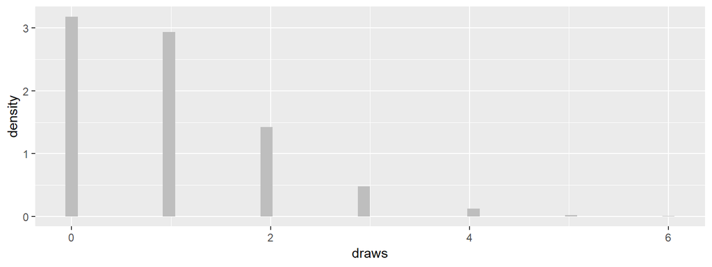

```r
require(ggplot2); set.seed(8675309)
# Poisson distribution doesn't have default lambda, checks if the input radio
# button (called dist) is for the Poisson distribution, and puts in lambda
if(as.character(input$dist) == "pois") draws <- rpois(input$numSamples, lambda = 1)
# ...
ggplot(data.frame(draws), aes(x = draws)) +
    geom_histogram(aes(fill = I("grey"), y = ..density..), bins = 50)
```

## Server Code Demonstration: Poission Means

Next, the server shows the distribution of `input$numSample` means (of sample size `input$sampleSize`). This allows the user to compare the two distributions.

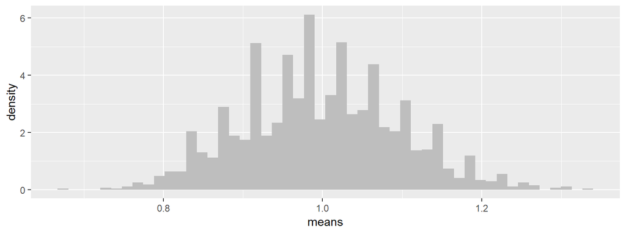

```r
require(ggplot2); set.seed(8675309)
if(as.character(input$dist) == "pois") {
    vals <- NULL
    for(i in 1:input$numSamples)  vals <- rbind(vals, rpois(input$sampleSize, lambda = 1))
}
means <- rowMeans(vals)
ggplot(data.frame(means), aes(x = means)) +
    geom_histogram(aes(fill = I("grey"), y = ..density..), bins = 50)
```